# PIXAR

Isis Maranhão

22/02/2022

# **Introdução**:

*Pixar Animation Studios*, conhecida mundialmente como Pixar, foi fundada em 03 de fevereiro de 1986.

Inicialmente, o estúdio era uma divisão da Lucasfilm. Recebeu o financiamento do co-fundador da Apple, Steve Jobs, que se tornou seu acionista majoritário. Algumas referência dizem que o começo de sua história está igualmente relacionado a um clipe animado de uma mão esquerda, a um dos criadores da Apple, e claro, à própria The Walt Disney Company.

Para quem tiver a mesma curiosidade, esse é o link para o vídeo referido acima. Está disponível no youtube.

[Vídeo: https://www.youtube.com/watch?v=wdedV81UQ5k&t=22s](https://www.youtube.com/watch?v=wdedV81UQ5k&t=22s)

A Walt Disney anunciou em 2006 a aquisição da Pixar Animation Studios por US$ 7,4 bilhões em ações. Esse negócio buscava restaurar a importância da Disney no segmento de animação infantil e levar Steve Jobs, presidente da Pixar e da Apple da época, a uma posição de destaque na Disney.

## Luxo Jr.

*Não sabe nada sobre Luxo jr?*

[figure not shown]

Luxo Jr.

Luxo Jr. foi a segunda curta-metragem produzida pela Pixar Animation Studios. Foi um filme de curta-metragem de animação feito com computação gráfica em 1986.

Ele pode ser visto esmagando o “I” da Pixar no início de cada filme produzido pelo estúdio de animação.

[figure not shown]

Luxo Jr.: outubro de 2021

No link abaixo você pode ver o vídeo mais atual desse curta no *Youtube*.

https://www.youtube.com/watch?v=FI0T0Oj7WFE

### As premiações de Luxo Jr.

E brilhante o quanto esse curta pode mostrar que é possível passar sentimentos através de uma animação em 3D, mesmo se o personagem for uma lâmpada.

Por conta desse extraordinário feito recebeu os seguintes prêmios e indicações:

O Luxo Jr. não ficou só nesse curta, ele também protagonizou mais curtas-metragens de animação feitos com computação gráfica em 1990 pela Pixar Animation Studios. São eles:

- Leve e Pesado (Light & Heavy)
- Surpresa (Surprise)
- Em Cima e em Baixo (Up and Down)
- Em Frente e Atrás (Front and Back)

**PRÊMIOS DO FILME LUXO JR.**

| id | ANO | PRÊMIO | CATEGORIA | RESULTADO |
| --- | --- | --- | --- | --- |
| 1 | 1986 | Oscar | Melhor Curta Animado | Apenas indicado |
| 2 | 1987 | Festival Internacional de Filmes em Berlin | Melhor Filme de Curta-metragem | Ganhou |
| 3 | 1987 | Festival Internacional de Animação em Ottawa | Melhor filme com menos de 5 minutos | Ganhou em 2° lugar |
| 4 | 1987 | Celebração Mundial de Animação | Animação Assistida de Computador | Ganhou |

# **Dados da Pixar**:

Usando os dados dispóníveis no *pacote dados* que foram traduzidos e disponibilizados numa versão em português.

[Dados: Filmes Pixar](https://cienciadedatos.github.io/dados/)

É fato que a empresa é refênrencia quando estamos falando sobre filmes de animação. A quatidade de prêmios que a **PIXAR** ganhou, com os seus filmes mais conhecidos pelo grande público, estão no gráfico abaixo.

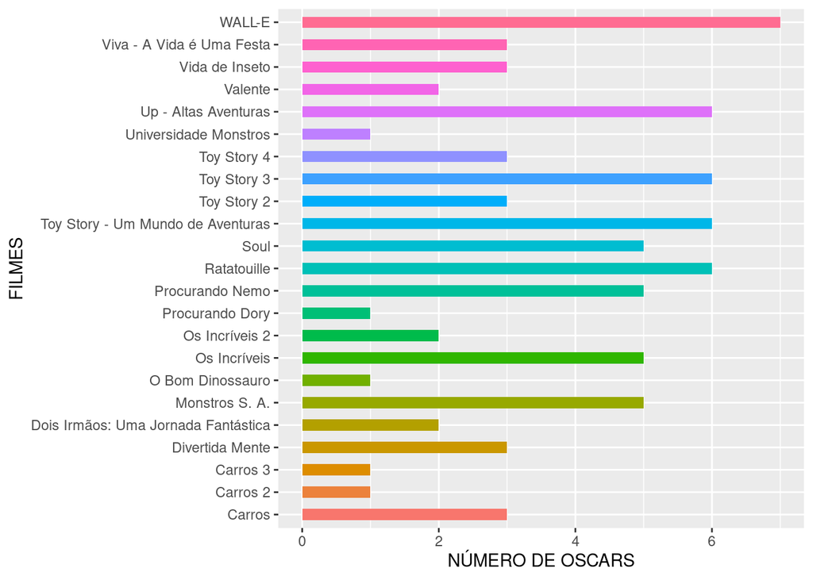

Olhando para a base de dados acima, podemos usar a *função do R: summary()*. Essa função calcula um resumo estatístico dos dados e objetos de uma base de dados.

```
##     filme           nota_rotten_tomatoes nota_metacritic bilheteria_mundial
##  Length:23          Min.   : 40.00       Min.   :57.00   Min.   :1.354e+08
##  Class :character   1st Qu.: 84.00       1st Qu.:71.00   1st Qu.:4.230e+08
##  Mode  :character   Median : 96.00       Median :81.00   Median :6.237e+08
##                     Mean   : 89.17       Mean   :79.96   Mean   :6.358e+08
##                     3rd Qu.: 97.50       3rd Qu.:90.00   3rd Qu.:8.323e+08
##                     Max.   :100.00       Max.   :96.00   Max.   :1.243e+09
##    orcamento
##  Min.   : 30000000
##  1st Qu.:120000000
##  Median :175000000
##  Mean   :156565217
##  3rd Qu.:192500000
##  Max.   :200000000
```

Como uma forma simples de aplicar matemática nos dados da *PIXAR*, vamos aplicar um modelo de regressão linear para avaliar a relação entre as duas vaiáveis quantititivas, no nosso caso, bilheteria_mundial e orcamento dos filmes.

Sem entrar muito na teoria matemática, queremos encontrar um modelo que descreva a seguinte exressão

$$y = a + bx$$

Abaixo é possível ver os resultados da *função do R: summary()* ao resultado. Nesse resultado tem vários pontos inportantes

```
##
## Call:
## lm(formula = bilheteria_mundial ~ orcamento, data = selecao_1)
##
## Residuals:
##        Min         1Q     Median         3Q        Max
## -539565806 -166309089    6823841  157837088  514654078
##
## Coefficients:
##              Estimate Std. Error t value Pr(>|t|)
## (Intercept) 3.030e+08  2.123e+08   1.427    0.168
## orcamento   2.126e+00  1.302e+00   1.633    0.117
##
## Residual standard error: 285300000 on 21 degrees of freedom
## Multiple R-squared:  0.1127, Adjusted R-squared:  0.07046
## F-statistic: 2.668 on 1 and 21 DF,  p-value: 0.1173
```

```r
R2 <- (sum((selecao_1$yhat - mean(selecao_1$orcamento))^2))/
  ((sum((selecao_1$yhat - mean(selecao_1$orcamento))^2)) + (sum((selecao_1$erro)^2)))

round(R2, digits = 4)
```

```
## [1] 0.7629
```

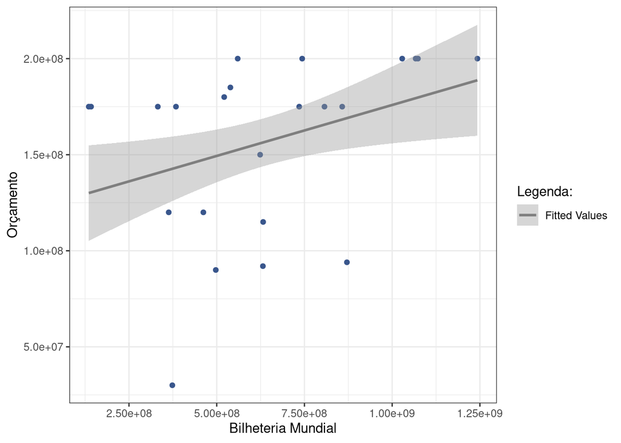

A regressão linear encontra a linha que melhor representa as variáveis de entrada com a variável de saída. É imaginar que o resultado *ótimo* entre o que se **arrecada na bilheteria** e o que foi **gasto para criar o filme** está na reta apresentada no gráfico acima.

Como resultado, o teste retornará a estatística W, que terá um valor de significância associada, o valor-p. Para dizer que uma distribuição é normal, o valor p precisa ser maior do que 0,05.

```
##
##  Shapiro-Francia normality test
##
## data:  modelo_filme$residuals
## W = 0.98036, p-value = 0.8444
```